# Rockfish Effort

### Unobserved Data (2007-2012 Shoreside only)

2007-2012: Shoreside– Use management code to ID trips.

2013-2017: [see observed data bc 100% census]

### Observed Data

This data uses “Unique trips observed.RDS”.

2007-2012: Shoreside: The data exists but having a hard time making it useful due to how trips are ID’ed. If I use management code to ID trips, I just get CP data. If I use management code and trip target code to ID trips I get SHoreside and CP, but then there is a mismatch between observed and total effort, where observed days dont seem to be accounted for in the fish ticket data in the way we are using it. CP: Because they dont use elandings fish ticket stuff I do not have info on unobserved effort for these, are they fully observed??

2013-2017: ID trips using RPP and target trip code, 100% observed. (CP and Shoreside, comes from “Unique trips observed.RDS”)

### 2013- 2017 Plot Effort (All Observed, 100% Census)

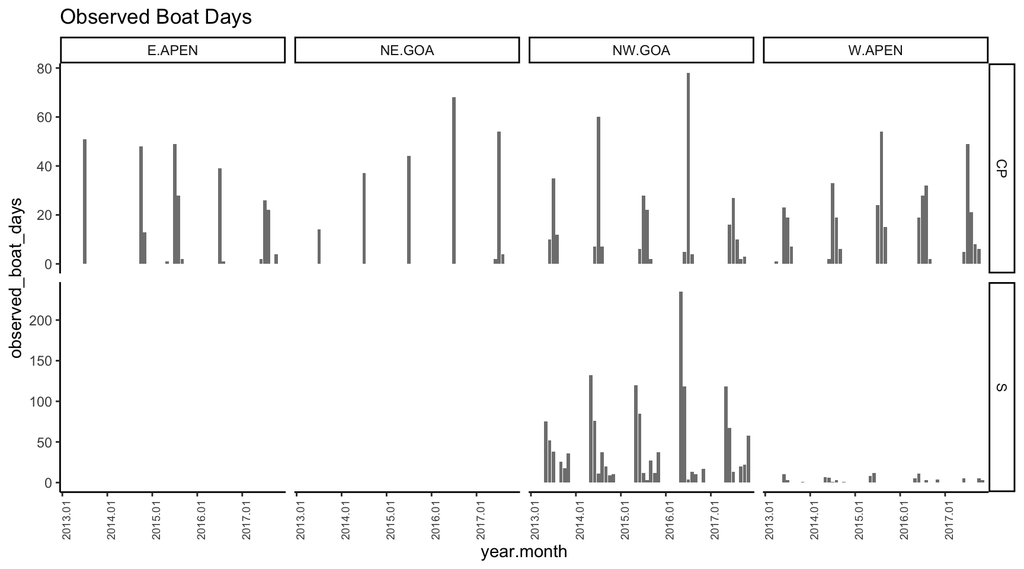

Now check seasonal coverage

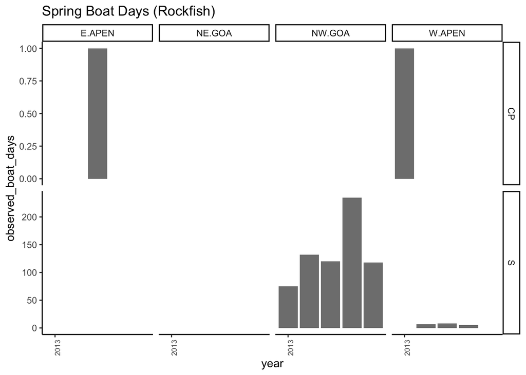

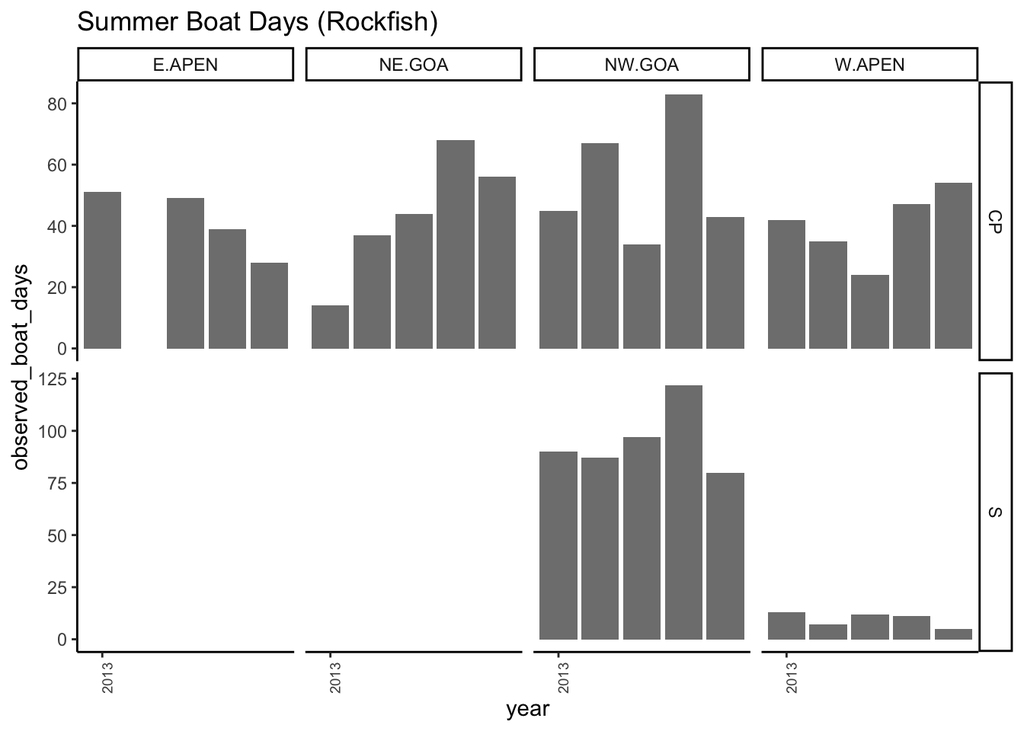

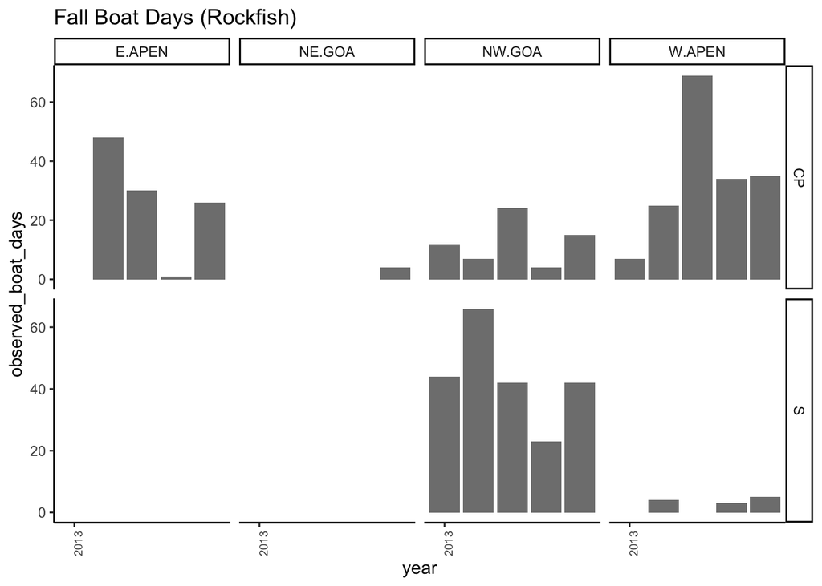

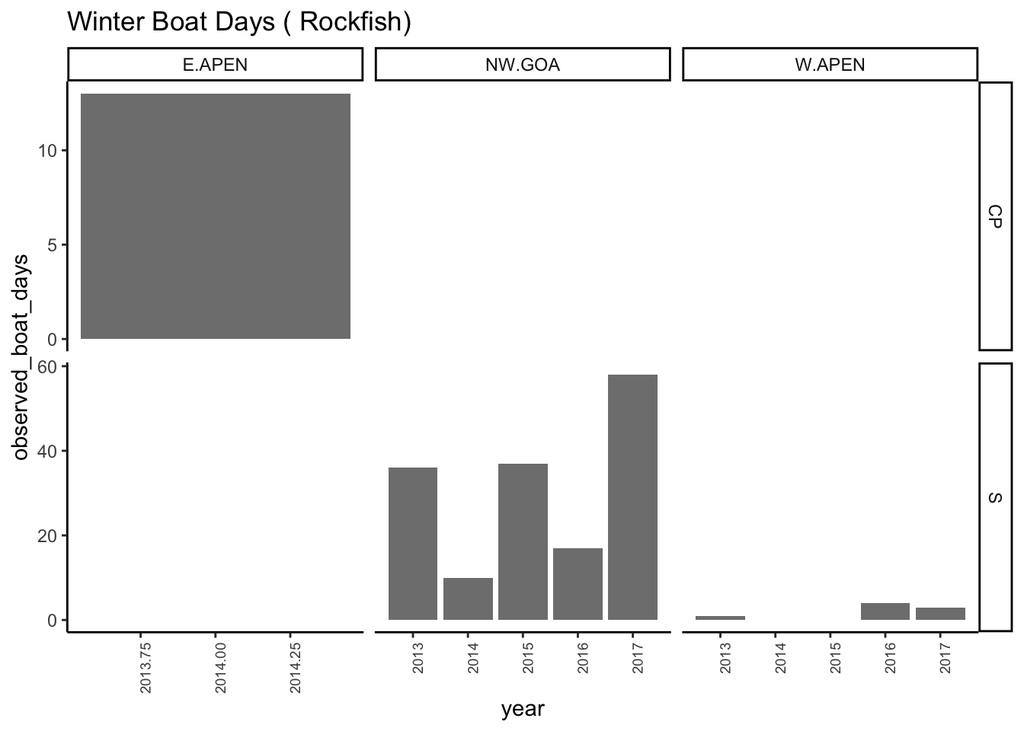

### Unobserved and Observed Effort Shoreside 2007-2012

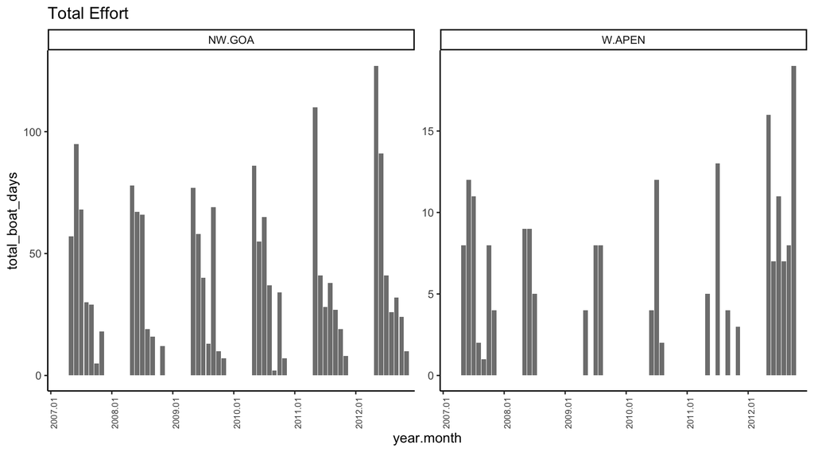

Seasonal for total effort

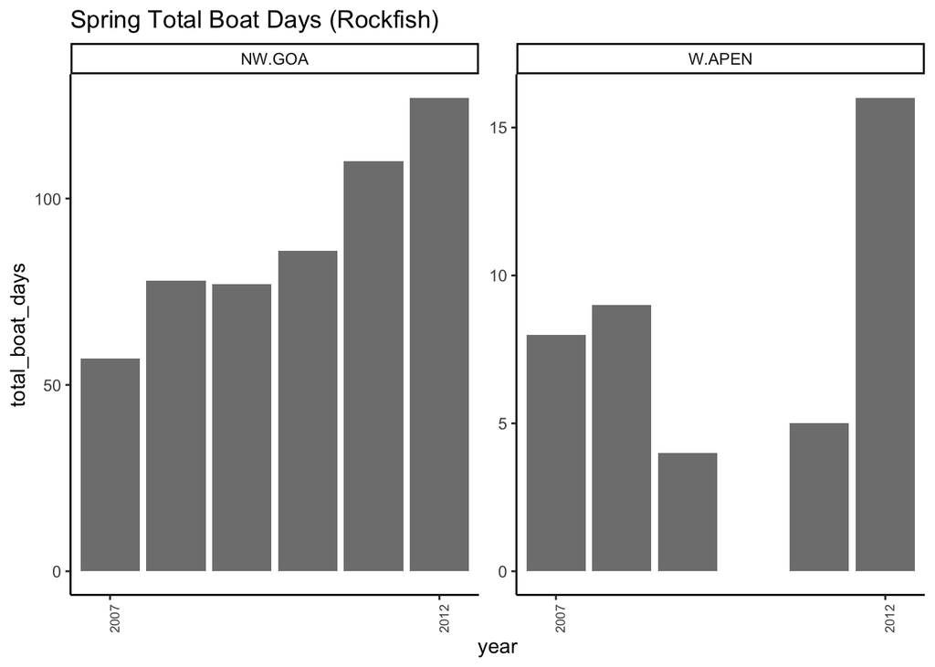

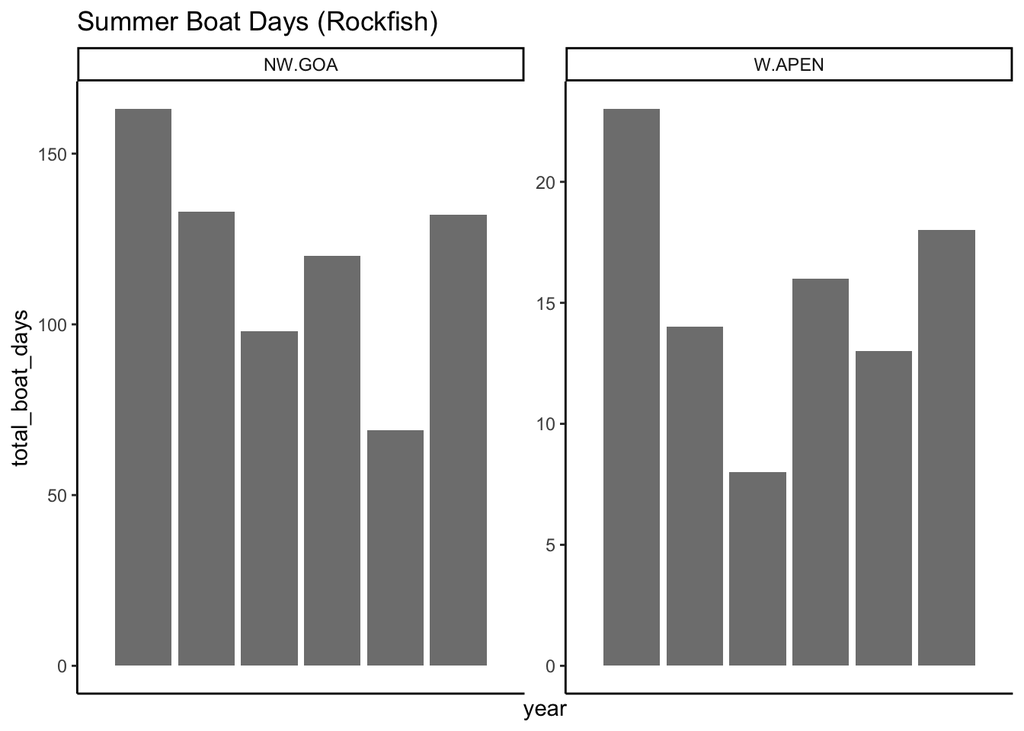

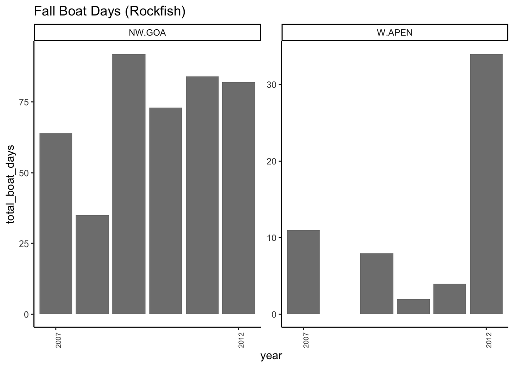

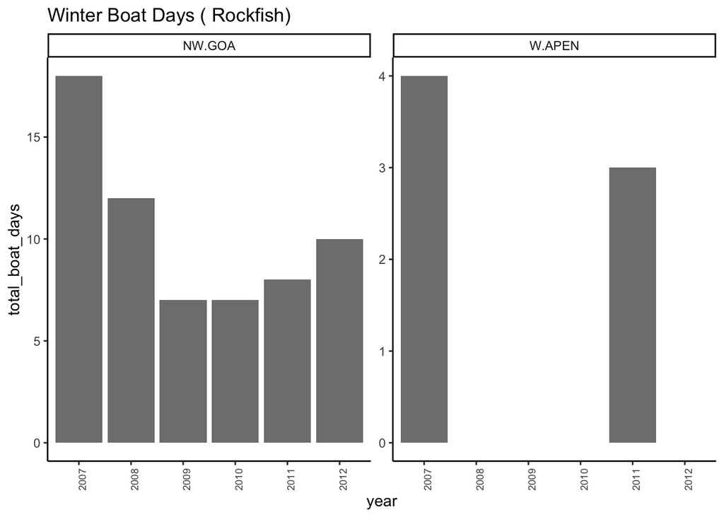

How does RMIS classify a rockfish trip? See last figure, RMIS recoveries and effort match better when I classify Rockfish trips using the target code rather than the management code

Does effort generally line up with recoveries? [Using Rockfish recovery data from JW and AFSC] Shoreside looks good, what is the deal with no recoveries for CP? This is better for trip target code than management code….

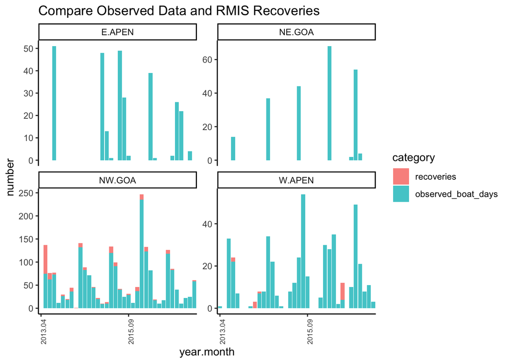